# Predicting the Stock Market

```python
import yfinance as yf
import pandas as pd
import matplotlib.pyplot as plt
import seaborn as sns

from sklearn.model_selection import train_test_split
from sklearn.ensemble import RandomForestClassifier
from sklearn.metrics import (
    accuracy_score,
    confusion_matrix,
    classification_report,
    roc_auc_score,
    roc_curve
)

from statsmodels.graphics.tsaplots import plot_acf
```

```python
# Load the S&P 500 data

ticket = "^GSPC"
df = yf.download(ticket, start="2000-01-01", end="2026-05-13")
df.head()
```

```
[*********************100%***********************]  1 of 1 completed
```

| Price Ticker Date | Close ^GSPC | High ^GSPC | Low ^GSPC | Open ^GSPC | Volume ^GSPC |
| --- | --- | --- | --- | --- | --- |
| 2000-01-03 | 1455.219971 | 1478.000000 | 1438.359985 | 1469.250000 | 931800000 |
| 2000-01-04 | 1399.420044 | 1455.219971 | 1397.430054 | 1455.219971 | 1009000000 |
| 2000-01-05 | 1402.109985 | 1413.270020 | 1377.680054 | 1399.420044 | 1085500000 |
| 2000-01-06 | 1403.449951 | 1411.900024 | 1392.099976 | 1402.109985 | 1092300000 |
| 2000-01-07 | 1441.469971 | 1441.469971 | 1400.729980 | 1403.449951 | 1225200000 |

```python
##########
# EDA
##########

# Basic structure and summary statistics

df.describe().T
```

| Price | Ticker | count | mean | std | min | 25% | 50% | 75% | max |
| --- | --- | --- | --- | --- | --- | --- | --- | --- | --- |
| Close | ^GSPC | 6629.0 | 2.331775e+03 | 1.540548e+03 | 676.530029 | 1.213540e+03 | 1.552480e+03 | 2.938130e+03 | 7.412840e+03 |
| High | ^GSPC | 6629.0 | 2.344624e+03 | 1.547240e+03 | 695.270020 | 1.220360e+03 | 1.557250e+03 | 2.947850e+03 | 7.428970e+03 |
| Low | ^GSPC | 6629.0 | 2.317148e+03 | 1.532519e+03 | 666.789978 | 1.205520e+03 | 1.545900e+03 | 2.919730e+03 | 7.384200e+03 |
| Open | ^GSPC | 6629.0 | 2.331384e+03 | 1.540119e+03 | 679.280029 | 1.213140e+03 | 1.552360e+03 | 2.934000e+03 | 7.390630e+03 |
| Volume | ^GSPC | 6629.0 | 3.447604e+09 | 1.526579e+09 | 0.000000 | 2.344350e+09 | 3.544330e+09 | 4.293240e+09 | 1.145623e+10 |

Observations:

- Pricing shows longer term upward drift
- Range is wide, confirming a broad financial dataset
- Volume has high spikes, which is useful for volatility analysis
- May want to remove days with 0 volume

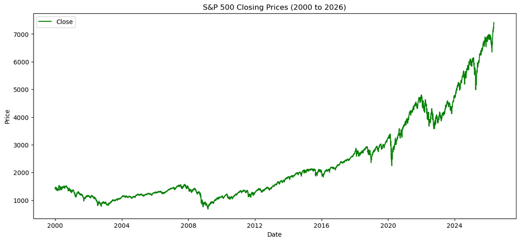

```python
##########
# EDA
##########

# Price trend

plt.figure(figsize=(14, 6))
plt.plot(df['Close'], label='Close', color='green')
plt.title("S&P 500 Closing Prices (2000 to 2026)")
plt.xlabel("Date")
plt.ylabel("Price")
plt.legend()
plt.show()
```

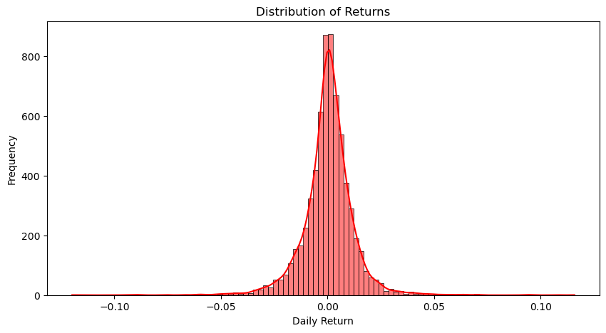

```python
##########
# EDA
##########

# Return distribution

df['Return'] = df['Close'].pct_change()

plt.figure(figsize=(10, 5))
sns.histplot(df['Return'], bins=100, kde=True, color='red')
plt.title("Distribution of Returns")
plt.xlabel("Daily Return")
plt.ylabel("Frequency")
plt.show()
```

Observations:

There is clustering around 0.00, suggesting most daily price changes are small, that the market shifts upward over long periods, but day to day is nearly random. This suggests prediction of direction is inherently challenging.

[figure not shown]

```python
##########
# EDA
##########

# Rolling volatility

plt.figure(figsize=(14, 6))
sns.histplot(df['Return'].rolling(20).std(), label='20 Day Volatility', color='blue')
plt.title("20 Day Rolling Volatility")
plt.xlabel("Date")
plt.ylabel("Volatility")
plt.show()
```

Observations:

There is a heavy concentration of volatility values between 0.005 and 0.01, a long right sided tail revealing a clear right skewed distribution, and a peak near 0.005 to 0.007. This suggests markets are mostly calm, as seen in the clustering around 1%, the narrow distribution on the left side, and the long right tail. This suggests modeling choices must handle regime shifts, time aware train/test splits, and volatility should be an included feature.

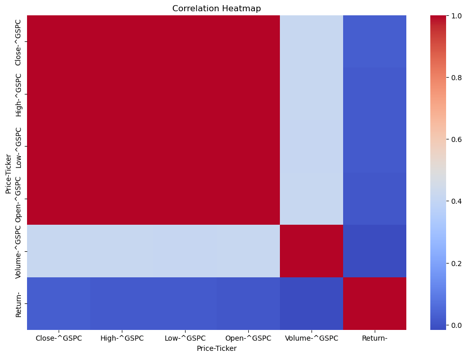

```python
##########
# EDA
##########

# Correlation heatmap

plt.figure(figsize=(12, 8))
sns.heatmap(df.corr(), annot=False, cmap='coolwarm')
plt.title("Correlation Heatmap")
plt.show()
```

Observations:

Open, High, Low, and Close all show correlations above 0.95 with each other. This suggests they all come from the same underlying price movement daily. More simply, if the market is up, all four tend to go up together. Unfortunately, this means those variables would be redundant together in machine learning models. But, this could mean Random Forest is a strong baseline choice.

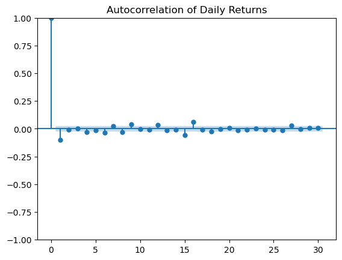

```python
##########
# EDA
##########

# Autocorrelation of returns

plt.figure(figsize=(10, 4))
plot_acf(df['Return'].dropna(), lags=30)
plt.title("Autocorrelation of Daily Returns")
plt.show()
```

Observations:

The single spike at lap 0 is always 1.0, as is the definition. All the other lags 1 to 30 are close to zero. This suggests there is no meaningful positive or negative autocorrelation. Which means today's return tells one nearly nothing about tomorrows. But, this could suggest a nonlinear model, like Random Forest, XGBoost, or neural nets, could be of assistance. The need for engineered features also arises again as the raw returns are not predictive.

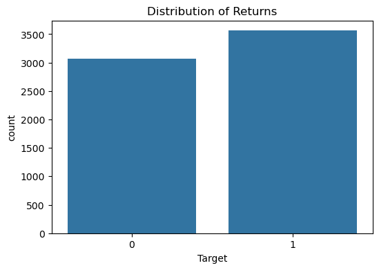

```python
##########
# EDA
##########

# Class balance for up vs down days

df['Target'] = (df['Return'].shift(-1) > 0).astype(int)

plt.figure(figsize=(6, 4))
sns.countplot(x=df['Target'])
plt.title("Distribution of Returns")
plt.show()
```

Observations:

This bar chart suggests that the market rises more than it falls. The dataset is mildly imbalanced, which means accuracy can be misleading; precision and recall become important, especially for the "class" class, and a confusion matrix may be essential to show whether the model is missing down days, overpredicting up days, or otherwise.

```python
##########
# End to End Pipeline After EDA
##########

# Flatten multiindex columns, head() showed a 2 level column index, only need the first level, which contains
# 'Close', 'Open', 'High', 'Low', 'Volume', and 'Price'

df.columns = [col[0] for col in df.columns]

# Drop redundant 'Price' as it mirrors 'Close' in the data

if 'Price' in df.columns:
    df.drop(columns=['Price'], inplace=True)

# Inspect the structure

df.head()
df.describe().T
```

|  | count | mean | std | min | 25% | 50% | 75% | max |
| --- | --- | --- | --- | --- | --- | --- | --- | --- |
| Close | 6629.0 | 2.331775e+03 | 1.540548e+03 | 676.530029 | 1.213540e+03 | 1.552480e+03 | 2.938130e+03 | 7.412840e+03 |
| High | 6629.0 | 2.344624e+03 | 1.547240e+03 | 695.270020 | 1.220360e+03 | 1.557250e+03 | 2.947850e+03 | 7.428970e+03 |
| Low | 6629.0 | 2.317148e+03 | 1.532519e+03 | 666.789978 | 1.205520e+03 | 1.545900e+03 | 2.919730e+03 | 7.384200e+03 |
| Open | 6629.0 | 2.331384e+03 | 1.540119e+03 | 679.280029 | 1.213140e+03 | 1.552360e+03 | 2.934000e+03 | 7.390630e+03 |
| Volume | 6629.0 | 3.447604e+09 | 1.526579e+09 | 0.000000 | 2.344350e+09 | 3.544330e+09 | 4.293240e+09 | 1.145623e+10 |
| Return | 6628.0 | 3.194466e-04 | 1.215871e-02 | -0.119841 | -4.720407e-03 | 6.391192e-04 | 5.902152e-03 | 1.158004e-01 |
| Target | 6629.0 | 5.373359e-01 | 4.986417e-01 | 0.000000 | 0.000000e+00 | 1.000000e+00 | 1.000000e+00 | 1.000000e+00 |

```python
#########
# Feature Engineering
#########

# Return and Target

# Return is stationary, while price is not. Target predicts the next day's direction.

df['Return'] = df['Close'].pct_change()
df['Target'] = (df['Return'].shift(-1) > 0).astype(int)

# Moving averages

# Trend extractions aim to reduce noise and capture short/medium/long term behaviors

df['MA5'] = df['Close'].rolling(5).mean()
df['MA20'] = df['Close'].rolling(20).mean()
df['MA50'] = df['Close'].rolling(50).mean()

# Volatility

# The volatility histogram showed clustering; volatility is predictive of regime shift

df['Volatility20'] = df['Return'].rolling(20).std()

# Momentum

# Moment to capture medium term directional pressures

df['Momentum'] = df['Close'] - df['Close'].shift(10)

# RSI

def compute_rsi(series, period=14):
    delta = series.diff()
    gain = delta.clip(lower=0)
    loss = -delta.clip(upper=0)
    avg_gain = gain.rolling(period).mean()
    avg_loss = loss.rolling(period).mean()
    rs = avg_gain / avg_loss
    return 100 - (100 / (1 + rs))

df['RSI'] = compute_rsi(df['Close'])

# MACD

ema12 = df['Close'].ewm(span=12, adjust=False).mean()
ema26 = df['Close'].ewm(span=26, adjust=False).mean()

df['MACD'] = ema12 - ema26
df['Signal'] = df['MACD'].ewm(span=9, adjust=False).mean()
```

```python
# Drop NaN

df.dropna(inplace=True)
```

```python
# Feature matrix and target vector

features = [
    'Return', 'MA5', 'MA20', 'MA50',
    'Volatility20', 'Momentum',
    'RSI', 'MACD', 'Signal'
]

X = df[features]
y = df['Target']
```

```python
# Time aware train and test split

# Reducing shuffling to prevent any look ahead, the last 20% will simulate future unseen data

X_train, X_test, y_train, y_test = train_test_split(
    X, y, test_size=0.2, shuffle=False
)
```

```python
# Train the random forest model

model = RandomForestClassifier(
    n_estimators=300,
    random_state=69,
    n_jobs=-1
)

model.fit(X_train, y_train)
```

```
RandomForestClassifier(n_estimators=300, n_jobs=-1, random_state=69)
```

```python
# Predictions and Metrics

y_pred = model.predict(X_test)

print("Accuracy:", accuracy_score(y_test, y_pred))
print("\nClassification Report:\n", classification_report(y_test, y_pred))
```

```
Accuracy: 0.493161094224924

Classification Report:
               precision    recall  f1-score   support

           0       0.46      0.56      0.51       611
           1       0.53      0.43      0.48       705

    accuracy                           0.49      1316
   macro avg       0.50      0.50      0.49      1316
weighted avg       0.50      0.49      0.49      1316
```

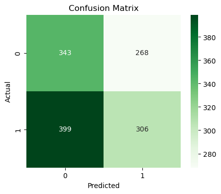

```python
# Confusion matrix

cm = confusion_matrix(y_test, y_pred)

plt.figure(figsize=(5,4))
sns.heatmap(cm, annot=True, fmt='d', cmap='Greens')
plt.title("Confusion Matrix")
plt.xlabel("Predicted")
plt.ylabel("Actual")
plt.show()
```

```
ROC-AUC: 0.4868219753688292
```

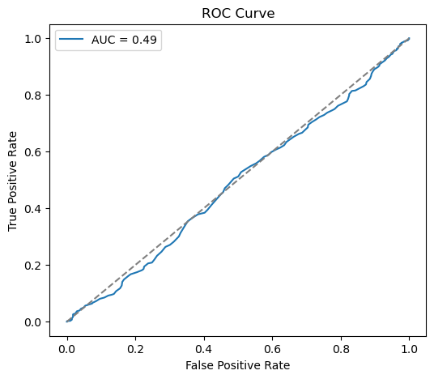

```python
# ROC-AUC

y_proba = model.predict_proba(X_test)[:, 1]

roc_auc = roc_auc_score(y_test, y_proba)
print("ROC-AUC:", roc_auc)

fpr, tpr, thresholds = roc_curve(y_test, y_proba)

plt.figure(figsize=(6,5))
plt.plot(fpr, tpr, label=f"AUC = {roc_auc:.2f}")
plt.plot([0,1], [0,1], linestyle='--', color='gray')
plt.title("ROC Curve")
plt.xlabel("False Positive Rate")
plt.ylabel("True Positive Rate")
plt.legend()
plt.show()
```

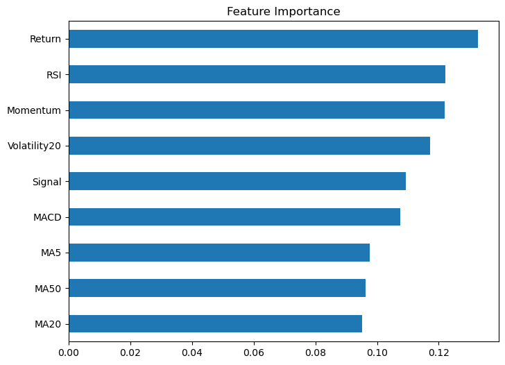

```python
# Feature importance

importance = pd.Series(model.feature_importances_, index=features).sort_values()

plt.figure(figsize=(8,6))
importance.plot(kind='barh')
plt.title("Feature Importance")
plt.show()
```

Observations:

Current modeling reveals performance is at a chance level, where ROC_AUC ≈ is 0.49, suggesting the signal is not present in the features. Next steps will be to extract the signal, improve feature engineering, upgrade the model, and adjust the prediction horizon.

```python
#########
# Feature Engineering Model 2
#########

# New feature engineering, Lagged returns; momentum plus mean reversion

df['Return_1'] = df['Return'].shift(1)
df['Return_2'] = df['Return'].shift(2)
df['Return_5'] = df['Return'].shift(5)
df['Return_10'] = df['Return'].shift(10)
```

```python
# Rolling returns

df['Rolling5'] = df['Return'].rolling(5).mean()
df['Rolling10'] = df['Return'].rolling(10).mean()
df['Rolling20'] = df['Return'].rolling(20).mean()
```

```python
# Price to moving average ratios

df['Close_MA5'] = df['Close'] / df['MA5']
df['Close_MA20'] = df['Close'] / df['MA20']
df['Close_MA50'] = df['Close'] / df['MA50']
```

```python
# Volatility features

df['Volatility20'] = df['Return'].rolling(20).std()
df['VolRatio'] = df['Volatility20'] / df['Volatility20'].rolling(50).mean()
df['VolChange'] = df['Volatility20'].pct_change()
```

```python
# Updated feature set

features = [
    # Base

    'Return',

    # Lagged returns

    'Return_1', 'Return_2', 'Return_5', 'Return_10',

    # Rolling returns

    'Rolling5', 'Rolling10', 'Rolling20',

    #Trend indicators

    'MA5', 'MA20', 'MA50',

    # Price to moving average ratios

    'Close_MA5', 'Close_MA20', 'Close_MA50',

    # Volatility refime features

    'Volatility20', 'VolRatio', 'VolChange',

    # Momentum plus oscillators

    'Momentum', 'RSI', 'MACD', 'Signal'
]

X = df[features]
y = df['Target']
```

```python
# Time aware train and test split

# Reducing shuffling to prevent any look ahead, the last 20% will simulate future unseen data

X_train, X_test, y_train, y_test = train_test_split(
    X, y, test_size=0.2, shuffle=False
)
```

```python
# Train the random forest model

model2 = RandomForestClassifier(
    n_estimators=400,
    max_depth=None,
    min_samples_split=5,
    min_samples_leaf=3,
    random_state=69,
    n_jobs=-1
)

model2.fit(X_train, y_train)
```

```
RandomForestClassifier(min_samples_leaf=3, min_samples_split=5,
                       n_estimators=400, n_jobs=-1, random_state=69)
```

```python
# Predictions and metrics (model2)

y_pred2 = model2.predict(X_test)

print("Accuracy:", accuracy_score(y_test, y_pred2))
print("\nClassification Report:\n", classification_report(y_test, y_pred2))
```

```
Accuracy: 0.5182370820668692

Classification Report:
               precision    recall  f1-score   support

           0       0.46      0.24      0.32       611
           1       0.54      0.76      0.63       705

    accuracy                           0.52      1316
   macro avg       0.50      0.50      0.47      1316
weighted avg       0.50      0.52      0.48      1316
```

Observations:

Accuracy is 0.518, a small improvement over Model 1, suggesting the model is learning something. Class 0, down days, is missing 76% of down days. Class 1 up days have a recall of 0.76, suggesting this is the only reason accuracy is above random.

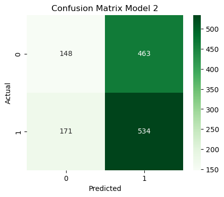

```python
# Confusion matrix (model2)

cm2 = confusion_matrix(y_test, y_pred2)

plt.figure(figsize=(5,4))
sns.heatmap(cm2, annot=True, fmt='d', cmap='Greens')
plt.title("Confusion Matrix Model 2")
plt.xlabel("Predicted")
plt.ylabel("Actual")
plt.show()
```

Observations:

The matrix shows 148 true negatives and 534 true positives, confirming the model is biased toward predicting Up days and misses most Down days.

```
ROC-AUC Model 2: 0.4896751053383013
```

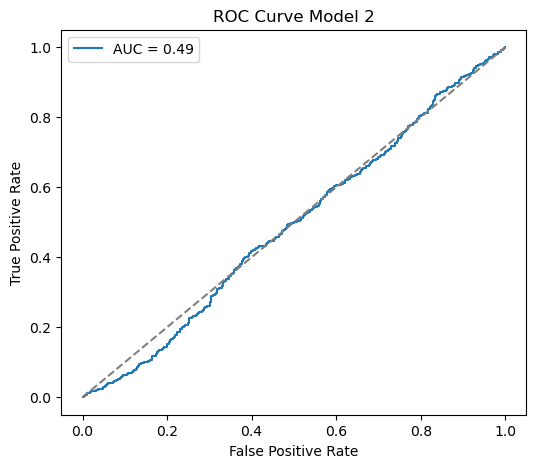

```python
# ROC-AUC (model2)

y_proba2 = model2.predict_proba(X_test)[:, 1]

roc_auc2 = roc_auc_score(y_test, y_proba2)
print("ROC-AUC Model 2:", roc_auc2)

fpr2, tpr2, thresholds2 = roc_curve(y_test, y_proba2)

plt.figure(figsize=(6,5))
plt.plot(fpr2, tpr2, label=f"AUC = {roc_auc2:.2f}")
plt.plot([0,1], [0,1], linestyle='--', color='gray')
plt.title("ROC Curve Model 2")
plt.xlabel("False Positive Rate")
plt.ylabel("True Positive Rate")
plt.legend()
plt.show()
```

Observations:

ROC-AUC of 0.4897 suggests the model is not ranking Up vs Down days and not learning a meaningful decision boundary.

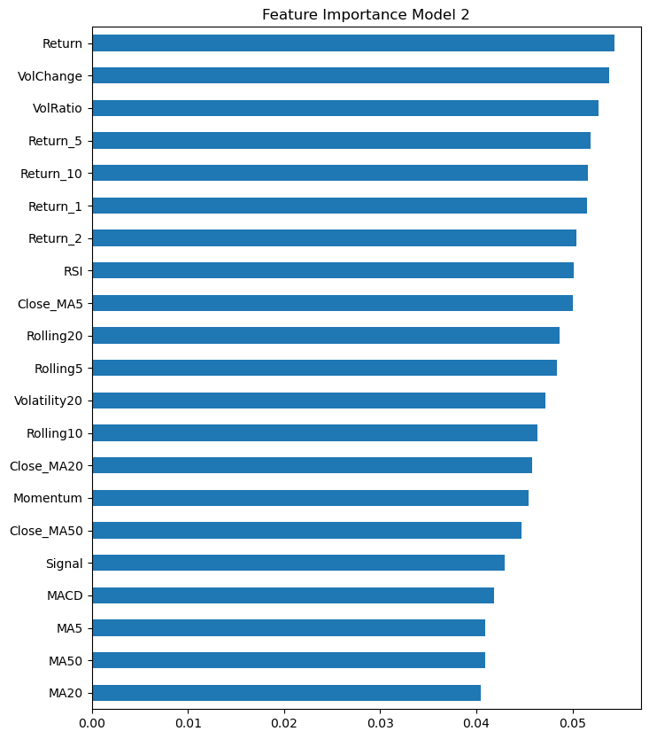

```python
# Feature importance (model2)

importance2 = pd.Series(model2.feature_importances_, index=features).sort_values()

plt.figure(figsize=(8,10))
importance2.plot(kind='barh')
plt.title("Feature Importance Model 2")
plt.show()
```

Observations:

Accuracy moved up from 0.49 to 0.518, suggesting the model is learning. ROC-AUC did not significantly improve, going from 0.486 to 0.489. This means the model is not sufficiently ranking up vs down days and is still not learning a meaningful decision boundary. This bias is confirmed by the confusion matrix, where it correctly identified 76% up days. Feature importance suggests that the model is still shallow, with Return, VolChange, and VolRatio high on the list. All of this suggests a Model 3 Random Forest isn't appropriate as Model 2 has hit its limit, suggesting the time has come to move to XGBoost.

```python
#########
# XGBoost Pipeline
#########

# Setup, same evaluation framework to compare models equally

from xgboost import XGBClassifier
```

```python
# Feature matrix and train/test split (model 3)

# Same features, isolates the effect of model change, and at the same time aware split for fair comparison

X = df[features]
y = df['Target']

X_train, X_test, y_train, y_test = train_test_split(
    X, y, test_size=0.2, shuffle=False
)
```

```python
# Define XGBoost Model (model 3)

model3 = XGBClassifier(
    n_estimators=400,
    max_depth=4, # Deep enough to capture interactions and avoid noise
    learning_rate=0.05, # Small steps for stability
    subsample=0.8, # Add randomness and reduce overfitting
    colsample_bytree=0.8, # Feature subsampling per tree

    objective='binary:logistic',
    eval_metric='logloss',
    random_state=69,
    n_jobs=1
)
```

```python
# Train the model (model 3)

model3.fit(X_train, y_train)
```

```
XGBClassifier(base_score=None, booster=None, callbacks=None,
              colsample_bylevel=None, colsample_bynode=None,
              colsample_bytree=0.8, device=None, early_stopping_rounds=None,
              enable_categorical=False, eval_metric='logloss',
              feature_types=None, feature_weights=None, gamma=None,
              grow_policy=None, importance_type=None,
              interaction_constraints=None, learning_rate=0.05, max_bin=None,
              max_cat_threshold=None, max_cat_to_onehot=None,
              max_delta_step=None, max_depth=4, max_leaves=None,
              min_child_weight=None, missing=nan, monotone_constraints=None,
              multi_strategy=None, n_estimators=400, n_jobs=1,
              num_parallel_tree=None, ...)
```

```python
# Predictions and metrics (model 3)

# Setup to be directly comparable to Models 1 and 2

y_pred3 = model3.predict(X_test)

print("Accuracy Model 3 XGBoost:", accuracy_score(y_test, y_pred3))
print("\nClassification Report Model 3 XGBoost:\n",
      classification_report(y_test, y_pred3))
```

```
Accuracy Model 3 XGBoost: 0.5258358662613982

Classification Report Model 3 XGBoost:
               precision    recall  f1-score   support

           0       0.48      0.25      0.33       611
           1       0.54      0.76      0.63       705

    accuracy                           0.53      1316
   macro avg       0.51      0.51      0.48      1316
weighted avg       0.51      0.53      0.49      1316
```

Observations:

Accuracy is 0.5258, a slight improvement over Model 2. Class 0, Down day, recall improved slightly, and Up day recall remained strong.

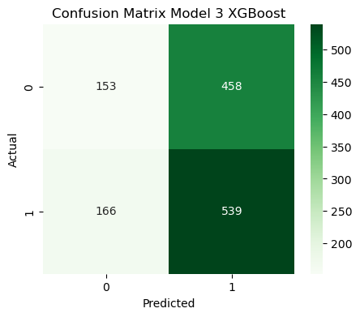

```python
# Confusion matrix

cm3 = confusion_matrix(y_test, y_pred3)

plt.figure(figsize=(5,4))
sns.heatmap(cm3, annot=True, fmt='d', cmap='Greens')
plt.title("Confusion Matrix Model 3 XGBoost")
plt.xlabel("Predicted")
plt.ylabel("Actual")
plt.show()
```

Observations:

True negatives are 153, and True positives are 539, a slight improvement over Model 2.

```
ROC-AUC Model 3: 0.5005954661002194
```

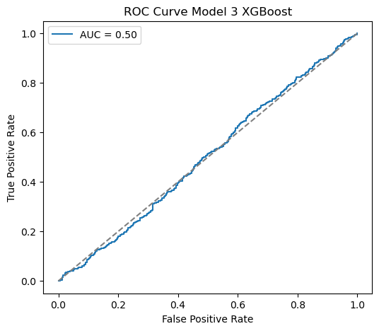

```python
# ROC-AUC (model3)

y_proba3 = model3.predict_proba(X_test)[:, 1]

roc_auc3 = roc_auc_score(y_test, y_proba3)
print("ROC-AUC Model 3:", roc_auc3)

fpr3, tpr3, thresholds3 = roc_curve(y_test, y_proba3)

plt.figure(figsize=(6,5))
plt.plot(fpr3, tpr3, label=f"AUC = {roc_auc3:.2f}")
plt.plot([0,1], [0,1], linestyle='--', color='gray')
plt.title("ROC Curve Model 3 XGBoost")
plt.xlabel("False Positive Rate")
plt.ylabel("True Positive Rate")
plt.legend()
plt.show()
```

Observations:

ROC-AUC is seen at 0.5005, equivalent to random guessing.

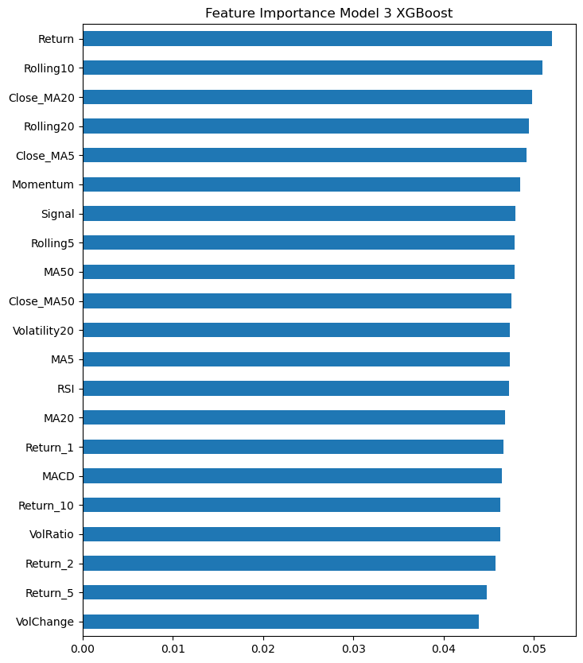

```python
# Feature importance (model 3)

importance3 = pd.Series(model3.feature_importances_, index=features).sort_values()

plt.figure(figsize=(8,10))
importance3.plot(kind='barh')
plt.title("Feature Importance Model 3 XGBoost")
plt.show()
```

```python
# Probability threshold tuning (model 3)

threshold = 0.55

y_pred3_thresh = (y_proba3 > threshold).astype(int)

print("Accuracy Model 3 where threshold is 0.55:", accuracy_score(y_test, y_pred3_thresh))
print("\nClassification Report Model 3 Where threshold is 0.55:\n",
      classification_report(y_test, y_pred3_thresh))
```

```
Accuracy Model 3 where threshold is 0.55: 0.526595744680851

Classification Report Model 3 Where threshold is 0.55:
               precision    recall  f1-score   support

           0       0.49      0.36      0.41       611
           1       0.55      0.67      0.60       705

    accuracy                           0.53      1316
   macro avg       0.52      0.52      0.51      1316
weighted avg       0.52      0.53      0.51      1316
```

Observations:

Threshold tuning appears to be working; more down days are caught, false positives are reduced, and improvements are seen in macro F1, weighted F1, and accuracy. Signs seen that signal potential structure. Will shift to a 5-day horizon pipeline as this single day prediction seems to have reached its limit.

```python
#########
# XGBoost Pipeline 5 Day Horizon
#########


# Construct the 5 day target

# Goal is to smooth out noise and capture the trend structure that 1 day returns could not

df['Return_5day'] = df['Close'].shift(-5) / df['Close'] - 1
df['Target5'] = (df['Return_5day'] > 0).astype(int)
```

```python
# Rebuild the Feature Matrix

# Previous features are designed for multi day prediction already

X = df[features]
y = df['Target5']
```

```python
# Same time aware split for fair comparison

X_train, X_test, y_train, y_test = train_test_split(
    X, y, test_size=0.2, shuffle=False
)
```

```python
# Define model 4

model4 = XGBClassifier(
    n_estimators=500,
    max_depth=4,
    learning_rate=0.03,
    subsample=0.8,
    colsample_bytree=0.8,
    objective='binary:logistic',
    eval_metric='logloss',
    random_state=69,
    n_jobs=1
)
```

```python
# Train model 4

model4.fit(X_train, y_train)
```

```
XGBClassifier(base_score=None, booster=None, callbacks=None,
              colsample_bylevel=None, colsample_bynode=None,
              colsample_bytree=0.8, device=None, early_stopping_rounds=None,
              enable_categorical=False, eval_metric='logloss',
              feature_types=None, feature_weights=None, gamma=None,
              grow_policy=None, importance_type=None,
              interaction_constraints=None, learning_rate=0.03, max_bin=None,
              max_cat_threshold=None, max_cat_to_onehot=None,
              max_delta_step=None, max_depth=4, max_leaves=None,
              min_child_weight=None, missing=nan, monotone_constraints=None,
              multi_strategy=None, n_estimators=500, n_jobs=1,
              num_parallel_tree=None, ...)
```

```python
# Predictions and metrics (model 4)

# Setup to be directly comparable to Models 1, 2, and 3

y_pred4 = model4.predict(X_test)

print("Accuracy Model 4:", accuracy_score(y_test, y_pred4))
print("\nClassification Report Model 4:\n",
      classification_report(y_test, y_pred4))
```

```
Accuracy Model 4: 0.5638297872340425

Classification Report Model 4:
               precision    recall  f1-score   support

           0       0.43      0.22      0.29       538
           1       0.60      0.80      0.68       778

    accuracy                           0.56      1316
   macro avg       0.52      0.51      0.49      1316
weighted avg       0.53      0.56      0.53      1316
```

Observations:

There is a meaningful jump from the 1 day models; this model has gone from model 3's 0.525 to model 4's 0.564. Class 0 sees recall at 0.22, suggesting the 5 day target is smoother and down periods are rarer. Class 1, up days, sees recall at 0.80, a larger improvement in the model's ability to detect multi day upward trends.

```python
# ROC-AUC (model 4)

y_proba4 = model4.predict_proba(X_test)[:, 1]

roc_auc4 = roc_auc_score(y_test, y_proba4)
print("ROC-AUC Model 4:", roc_auc4)
```

```
ROC-AUC Model 4: 0.48983429057444017
```

Observations:

ROC-AUC of 0.4898 suggests the 5 day horizon is worse than random guessing.

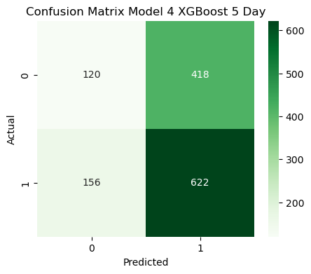

```python
# Confusion matrix (model 4)

cm4 = confusion_matrix(y_test, y_pred4)

plt.figure(figsize=(5,4))
sns.heatmap(cm4, annot=True, fmt='d', cmap='Greens')
plt.title("Confusion Matrix Model 4 XGBoost 5 Day")
plt.xlabel("Predicted")
plt.ylabel("Actual")
plt.show()
```

Observations:

622 true positives and 120 true negatives, suggesting the model is correctly identifying most 5 day "up" trends. However, the model is still not sufficiently identifying "down" trends, but the model is more confident overall.

[figure not shown]

```python
# Feature importance (model 4)

importance4 = pd.Series(model4.feature_importances_, index=features).sort_values()

plt.figure(figsize=(8,10))
importance3.plot(kind='barh')
plt.title("Feature Importance Model 4 XGBoost 5 Day")
plt.xlabel("Importance Score (Higher = greater importance)")
plt.ylabel("Feature")
plt.show()
```